# Google Trends Analysis

```r
## Load the necessary libraries
## Load in the necessary packages
library(dplyr)
library(ggplot2)
library(tidyr)
library(sf)
library(maps)
library(tidycensus)
library(tidyverse)
library(readxl)
library(moments)
library(boot)

## Read in the functions file for this project
source("./google_trends_functions.R")
```

## United States Example

This data has the same collection range as the United States data. It was collected roughly daily from October 2022 to January 2024. The time period for this data collection ranges from June 3rd, 2018 to September 4th, 2022

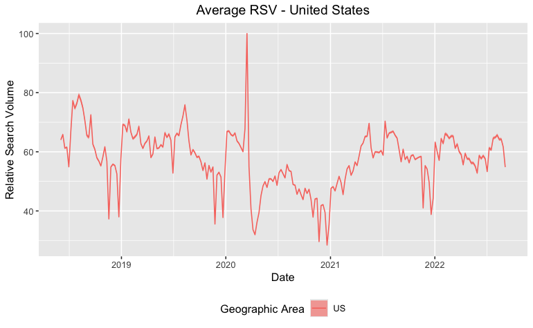

```r
## Plot the average relative search volume for the entire US
ggplot(data = time_data %>% filter(source == "US"), aes(x = time, y = average, group = source)) +
  geom_line(aes(color = source)) +
  geom_ribbon(aes(ymin = ci_lower, ymax = ci_upper, fill = source), alpha = 0.6) +
  ggtitle("Average RSV - United States") +
  theme(plot.title = element_text(hjust = 0.5)) +
  ylab("Relative Search Volume") +
  xlab("Date") +
  #theme(legend.title=element_blank()) +
  labs(fill = "Geographic Area", color = "Geographic Area") +
  theme(legend.position = "bottom")
```

In the graph above we can see a peak around the time when lockdowns started in the United States. Since that time period is captured in the data that will serve as the benchmark for greatest search intensity for childcare and will be converted to a score of 100. There was a sharp drop after this point and a small rise and return to normalcy towards the start of 2021. There is also an obvious seasonality in the trends for searching for child care that we should be cognizant of. Around the start of the holiday season there is a drop in the searches for child care and then a sharp spike after the start of the new year as people transition back into their regular working schedules. Searches increase at the start of summer when children are out of school but then drop as the summer wears on. What we are seeing above is an average of all of the data pools across the study period. There are also some consistent dips around November and December times when school lets out for the holidays and parents have those holidays off to watch their children.

In the US graph above we are using data for the entire collection time period, which is 243 data extractions. Based on Cebrian 2024, we know that if we limit the number of days that we average the sample, we can see different trends that don’t reflect a consistent measurement from Google Trends.

Let’s plot several iterations of this dataset by excluding parts of the sample and slowly building back up to the full sample.

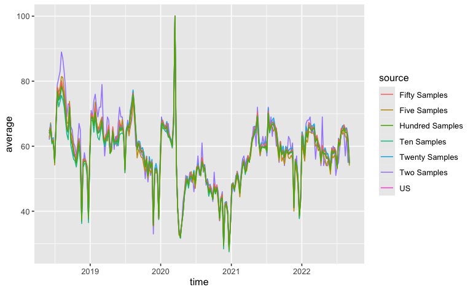

```r
## Pull one random sample from the data
one_sample <- us_raw %>% sample_n(1) %>% get_descriptive_stats_time() %>% add_date_column()
one_sample$source <- "One Sample"

two_samples <- us_raw %>% sample_n(2) %>% get_descriptive_stats_time() %>% add_date_column()
one_sample$source <- "Two Samples"

## Pull five random samples
five_samples <- us_raw %>% sample_n(5) %>% get_descriptive_stats_time() %>% add_date_column()
five_samples$source <- "Five Samples"

## Pull ten random samples
ten_samples <- us_raw %>% sample_n(10) %>% get_descriptive_stats_time() %>% add_date_column()
ten_samples$source <- "Ten Samples"

## Pull 20 random samples
twenty_samples <- us_raw %>% sample_n(20) %>% get_descriptive_stats_time() %>% add_date_column()
twenty_samples$source <- "Twenty Samples"

## Pull 50 random samples
fifty_samples <- us_raw %>% sample_n(50) %>% get_descriptive_stats_time() %>% add_date_column()
fifty_samples$source <- "Fifty Samples"

## Pull 100 random samples
hundred_samples <- us_raw %>% sample_n(100) %>% get_descriptive_stats_time() %>% add_date_column()
hundred_samples$source <- "Hundred Samples"

## Now plot all of these alongside the national level data
ggplot(data = us_descriptive, aes(x = time, y = average, group = source)) +
  geom_line(aes(color = source)) +
  geom_line(data = one_sample, aes(x = time, y = average, group = source, color = source)) +
  geom_line(data = five_samples, aes(x = time, y = average, group = source, color = source)) +
  geom_line(data = ten_samples, aes(x = time, y = average, group = source, color = source)) +
  geom_line(data = twenty_samples, aes(x = time, y = average, group = source, color = source)) +
  geom_line(data = fifty_samples, aes(x = time, y = average, group = source, color = source)) +
  geom_line(data = hundred_samples, aes(x = time, y = average, group = source, color = source))
```

```r
#ggplot(data = ten_samples, aes(x = time, y = average, group = 1)) + geom_line()
```

I need to restrict this sample to be the same time frame as the states. So it should be between 2020-02-09 to 2021-02-14.

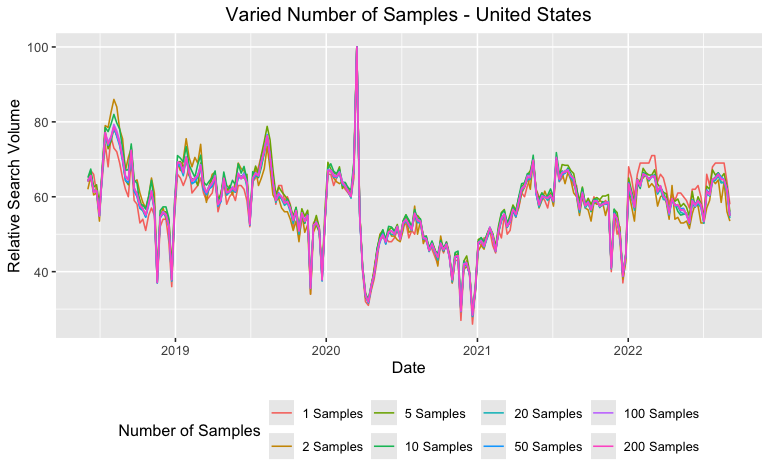

```r
us_plot <- create_sample_average_plot(us_raw, us_descriptive)
us_plot + ggtitle("Varied Number of Samples - United States")
```

Now run the code that creates replicates for each of the examples shown above so I can have a confidence interval for them.

[figure not shown]

```r
## Run the bootstrap replicate function
average_rsv_us <- boot_rsv(us_raw)

ggplot(data = average_rsv_us, aes(x = names, y = averages, group = names))
```

- Taking the mean of the standard deviations for the number of extractions. This can be done by simple using the mean command on the standard deviation column in the processed data.
- Calculate the MAPE to show the level of inconsistency associated with the data based on the number of extractions.

```r
## Get the popularity score and mape for five samples
get_popularity(five_samples)
```

```
[1] 1.999164
```

```r
get_mape(us_descriptive, five_samples)
```

```
[1] 1.777658
```

```r
get_theoretical_mape(get_popularity(five_samples),5)
```

```
[1] 1.239505
```

```r
get_samples(us_raw, 5)
```

|  | average | median | min | max | sd | var | skew | kurtosis | ci_lower | ci_upper | time | source |
| --- | --- | --- | --- | --- | --- | --- | --- | --- | --- | --- | --- | --- |
| 2018-06-03 | 66.6 | 66 | 64 | 71 | 2.7018512 | 7.3 | 0.89789570 | 2.505254 | 66.24539 | 66.95461 | 2018-06-03 | 5 Samples |
| 2018-06-10 | 66.4 | 65 | 63 | 73 | 4.2190046 | 17.8 | 0.78249282 | 2.145341 | 65.84626 | 66.95374 | 2018-06-10 | 5 Samples |
| 2018-06-17 | 61.6 | 61 | 54 | 71 | 6.1073726 | 37.3 | 0.47527672 | 2.504514 | 60.79841 | 62.40159 | 2018-06-17 | 5 Samples |
| 2018-06-24 | 62.4 | 62 | 61 | 65 | 1.6733201 | 2.8 | 0.73019589 | 2.133929 | 62.18038 | 62.61962 | 2018-06-24 | 5 Samples |
| 2018-07-01 | 55.8 | 56 | 54 | 57 | 1.3038405 | 1.7 | -0.36317347 | 1.628028 | 55.62887 | 55.97113 | 2018-07-01 | 5 Samples |
| 2018-07-08 | 66.8 | 67 | 64 | 70 | 2.1679483 | 4.7 | 0.28309221 | 2.358760 | 66.51546 | 67.08454 | 2018-07-08 | 5 Samples |
| 2018-07-15 | 77.2 | 77 | 75 | 80 | 1.9235384 | 3.7 | 0.39587034 | 1.994522 | 76.94754 | 77.45246 | 2018-07-15 | 5 Samples |
| 2018-07-22 | 73.8 | 70 | 70 | 80 | 5.2153619 | 27.2 | 0.42228374 | 1.197191 | 73.11549 | 74.48451 | 2018-07-22 | 5 Samples |
| 2018-07-29 | 76.4 | 73 | 72 | 84 | 5.3197744 | 28.3 | 0.59752404 | 1.617831 | 75.70179 | 77.09821 | 2018-07-29 | 5 Samples |
| 2018-08-05 | 79.2 | 76 | 74 | 91 | 6.9785385 | 48.7 | 1.14818503 | 2.705794 | 78.28407 | 80.11593 | 2018-08-05 | 5 Samples |

[output cut: 213 more lines]

```r
## Get the expected number of extractions for the data
## Not totally sure this works yet. Right now it is just returning what I put in. This may be because the US data does not need very many extractions for the data to be good. I need to do more testing with this when I do the different geographies.
get_expected_extractions(one_sample)
```

```
[1] NaN
```

```r
get_expected_extractions(two_samples)
```

```
[1] 0.3951306
```

```r
get_expected_extractions(five_samples)
```

```
[1] 0.3072747
```

```r
get_expected_extractions(ten_samples)
```

```
[1] 0.4377193
```

```r
get_expected_extractions(twenty_samples)
```

```
[1] 0.5476949
```

```r
get_expected_extractions(fifty_samples)
```

```
[1] 0.7015082
```

```r
get_expected_extractions(hundred_samples)
```

```
[1] 0.6128046
```

```r
## Holder vectors to create a dataframe afterward
pop_scores <- c()
mapes <- c()
t_mapes <- c() ## theoretical mapes
names <- c()

for (i in c(1,2,5,10,20,50,100)) {
  ## Get the samples
  s <- get_samples(us_raw, i)

  ## get the popularity score
  pop_score <- get_popularity(s)

  ## get the mape
  mape <- get_mape(us_descriptive, s)

  ## get the theoretical map based on Cebrian 2024
  t_mape <- get_theoretical_mape(pop_score,i)

  ## get the label so it can be added to the new dataframe
  name <- unique(s$source)

  ## append them to the appropriate lists
  pop_scores <- c(pop_scores, pop_score)
  mapes <- c(mapes, mape)
  t_mapes <- c(t_mapes, t_mape)
  names <- c(names, name)
}

## Build a dataframe from the data for plotting
comparison_df <- data.frame(pop_scores, mapes, t_mapes, names)

## Order the names so it prints coherently in the x-axis when plotted
comparison_df$names <- factor(comparison_df$names, levels = c("1 Samples", "2 Samples", "5 Samples", "10 Samples", "20 Samples", "50 Samples", "100 Samples"))

## colors so the plots look good
comparison_df$mape_color <- "Empirical"
comparison_df$tmapes_color <- "Theoretical"
```

Get the expected number of extractions

```r
us_extractions_df <- expected_extractions(us_raw)
```

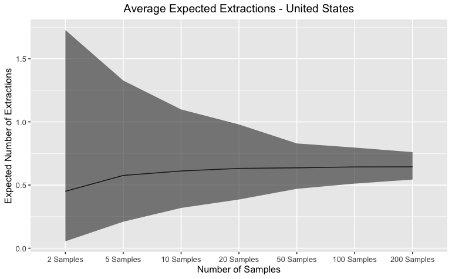

```r
ggplot(data = us_extractions_df, aes(x = names, y = mean_extractions, group = 1)) +
  geom_line() +
  geom_ribbon(aes(ymin = ci_lowers, ymax = ci_uppers), alpha = 0.6) +
  ggtitle("Average Expected Extractions - United States") +
  theme(plot.title = element_text(hjust = 0.5)) +
  ylab("Expected Number of Extractions") +
  xlab("Number of Samples") +
  #labs(fill = "Geographic Area", color = "Geographic Area") +
  theme(legend.position = "bottom")
```

```r
  #geom_line(aes(x = names, y = t_mapes, group = 1, color = tmapes_color))
```

```r
## Run the comparison df function for the US data
comparison_df_us <- create_comparison_df(us_raw, us_descriptive)
```

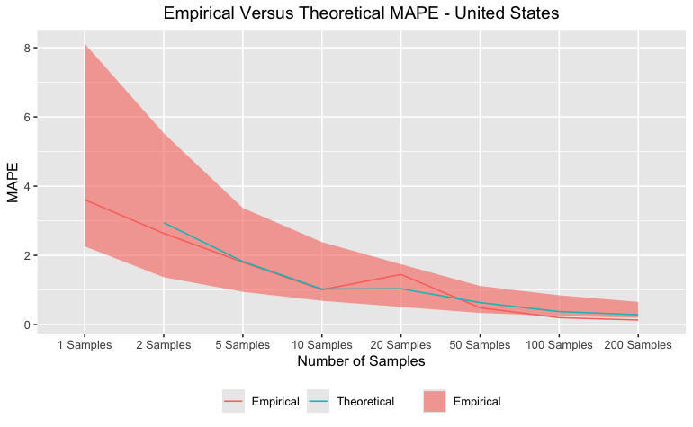

```r
## Plot the data from the code block above
ggplot(data = comparison_df_us, aes(x = names, y = mapes, group = mape_color)) +
  geom_ribbon(aes(ymin = ci_lowers, ymax = ci_uppers, fill = mape_color), alpha = 0.6) +
  geom_line(aes(color = mape_color)) +
  geom_line(aes(x = names, y = t_mapes, group = 1, color = tmapes_color)) +
  ggtitle("Empirical Versus Theoretical MAPE - United States") +
  theme(plot.title = element_text(hjust = 0.5)) +
  ylab("MAPE") +
  xlab("Number of Samples") +
  theme(legend.title=element_blank()) +
  #labs(fill = "Geographic Area", color = "Geographic Area") +
  theme(legend.position = "bottom")
```

```r
# ggplot(data = comparison_df_us) +
#   geom_line(aes(x = names, y = mapes, group = 1, color = mape_color)) +
#   geom_line(aes(x = names, y = t_mapes, group = 1, color = tmapes_color))
```

From the graph above, you can see that the US data, which has abundant and diverse sample size performs pretty well even with 1 to 5 extractions. Meaning that you can generally trust that you are at least getting a consistent Google Trends estimate when working at the country geographic level in the US. I am now going to try this with various other geographic levels to see how they behave.

## Oregon Example

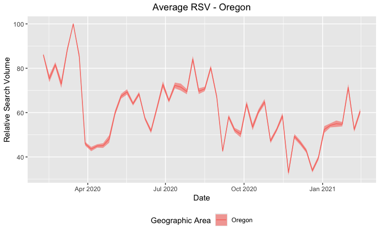

```r
## Plot the average relative search volume for the entire US
ggplot(data = time_data %>% filter(source == "Oregon"), aes(x = time, y = average, group = source)) +
  geom_line(aes(color = source)) +
  geom_ribbon(aes(ymin = ci_lower, ymax = ci_upper, fill = source), alpha = 0.6) +
  ggtitle("Average RSV - Oregon") +
  theme(plot.title = element_text(hjust = 0.5)) +
  ylab("Relative Search Volume") +
  xlab("Date") +
  #theme(legend.title=element_blank()) +
  labs(fill = "Geographic Area", color = "Geographic Area") +
  theme(legend.position = "bottom")
```

```r
## Create the comparison of extractions on averages
oregon_plot <- create_sample_average_plot(oregon_time, oregon_time_descriptive)
```

[output not shown]

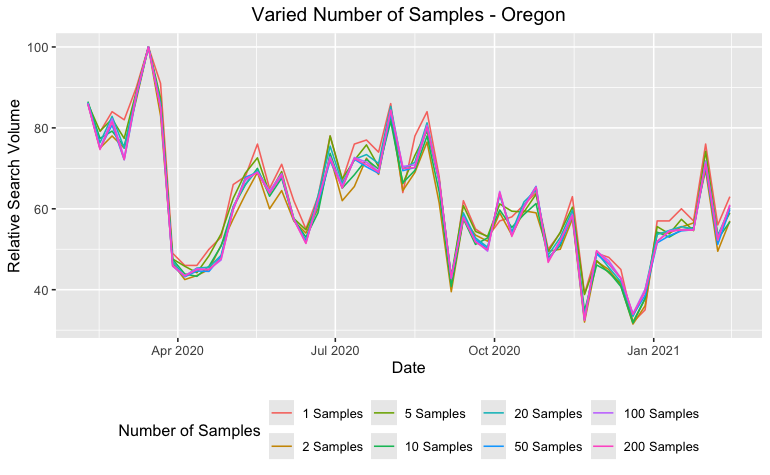

```r
oregon_plot + ggtitle("Varied Number of Samples - Oregon")
```

Get the expected number of extractions

```r
oregon_extractions_df <- suppressWarnings(expected_extractions(oregon_time))
```

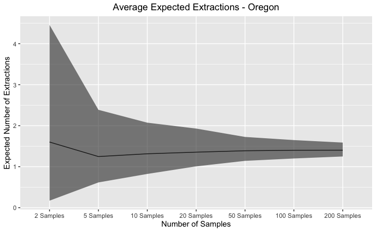

```r
ggplot(data = oregon_extractions_df, aes(x = names, y = mean_extractions, group = 1)) +
  geom_line() +
  geom_ribbon(aes(ymin = ci_lowers, ymax = ci_uppers), alpha = 0.6) +
  ggtitle("Average Expected Extractions - Oregon") +
  theme(plot.title = element_text(hjust = 0.5)) +
  ylab("Expected Number of Extractions") +
  xlab("Number of Samples") +
  #labs(fill = "Geographic Area", color = "Geographic Area") +
  theme(legend.position = "bottom")
```

```r
  #geom_line(aes(x = names, y = t_mapes, group = 1, color = tmapes_color))
```

```r
## Create comparison df for Indiana
comparison_df_oregon <- suppressWarnings(create_comparison_df(oregon_time, oregon_time_descriptive))
```

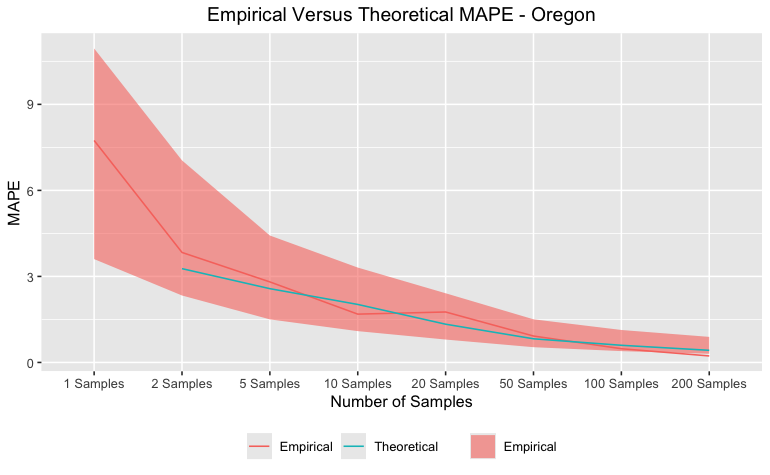

```r
## Plot the data from the code block above
ggplot(data = comparison_df_oregon, aes(x = names, y = mapes, group = mape_color)) +
  geom_line(aes(color = mape_color)) +
  geom_ribbon(aes(ymin = ci_lowers, ymax = ci_uppers, fill = mape_color), alpha = 0.6) +
  geom_line(aes(x = names, y = t_mapes, group = 1, color = tmapes_color)) +
  ggtitle("Empirical Versus Theoretical MAPE - Oregon") +
  theme(plot.title = element_text(hjust = 0.5)) +
  ylab("MAPE") +
  xlab("Number of Samples") +
  theme(legend.title=element_blank()) +
  #labs(fill = "Geographic Area", color = "Geographic Area") +
  theme(legend.position = "bottom")
```

## Eugene Example

Eugene is an example where there isn’t a uniform day when the average of one day equals 100, so it must be rescaled.

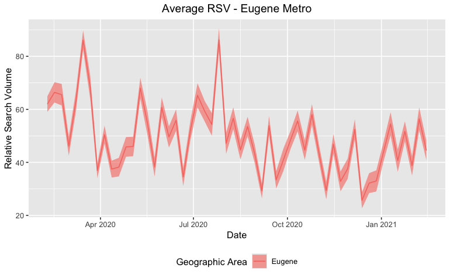

```r
## Plot the average relative search volume for the entire US
## Need to move the confidence intervals for this
ggplot(data = eugene_time_descriptive, aes(x = time, y = average, group = source)) +
  geom_line(aes(color = source)) +
  geom_ribbon(aes(ymin = ci_lower, ymax = ci_upper, fill = source), alpha = 0.6) +
  ggtitle("Average RSV - Eugene Metro") +
  theme(plot.title = element_text(hjust = 0.5)) +
  ylab("Relative Search Volume") +
  xlab("Date") +
  #theme(legend.title=element_blank()) +
  labs(fill = "Geographic Area", color = "Geographic Area") +
  theme(legend.position = "bottom")
```

```r
## rescale the Eugene data as per Cebrian 2024)
eugene_time_descriptive$average <- eugene_time_descriptive$average * (100/max(eugene_time_descriptive$average))
```

```r
## Create the comparison of extractions on averages
eugene_plot <- create_sample_average_plot(eugene_time, eugene_time_descriptive)
```

[output not shown]

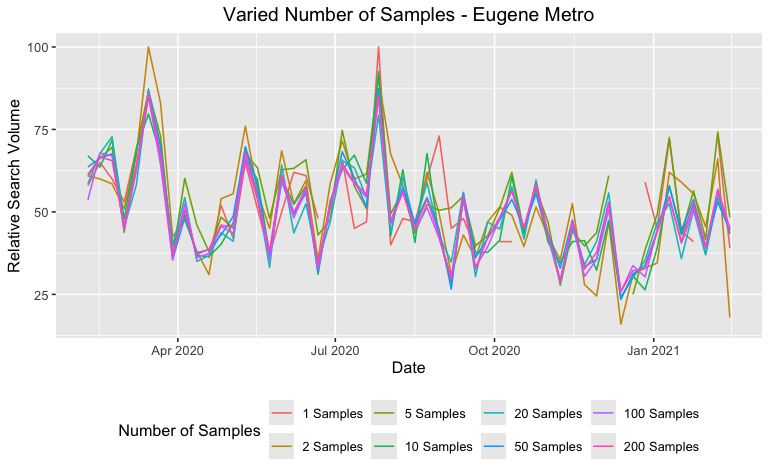

```r
eugene_plot + ggtitle("Varied Number of Samples - Eugene Metro")
```

Get the expected number of extractions

```r
eugene_extractions_df <- suppressWarnings(expected_extractions(eugene_time))
```

[output not shown]

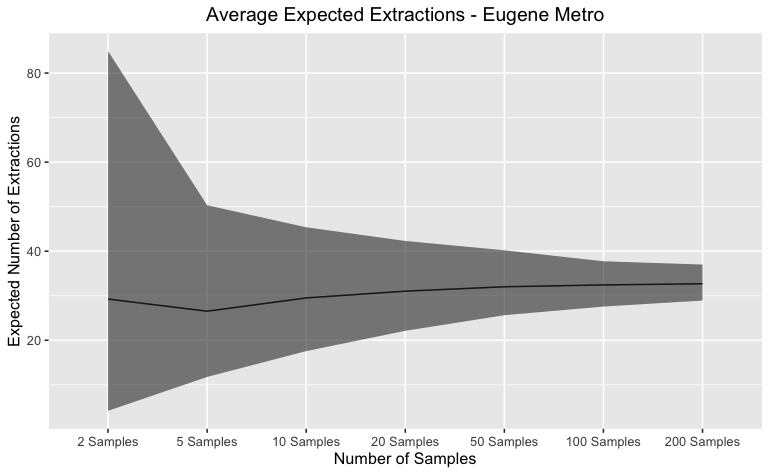

```r
ggplot(data = eugene_extractions_df, aes(x = names, y = mean_extractions, group = 1)) +
  geom_line() +
  geom_ribbon(aes(ymin = ci_lowers, ymax = ci_uppers), alpha = 0.6) +
  ggtitle("Average Expected Extractions - Eugene Metro") +
  theme(plot.title = element_text(hjust = 0.5)) +
  ylab("Expected Number of Extractions") +
  xlab("Number of Samples") +
  #labs(fill = "Geographic Area", color = "Geographic Area") +
  theme(legend.position = "bottom")
```

```r
  #geom_line(aes(x = names, y = t_mapes, group = 1, color = tmapes_color))
```

```r
## Create comparison df for Indiana
comparison_df_eugene <- suppressWarnings(create_comparison_df(eugene_time, eugene_time_descriptive))
```

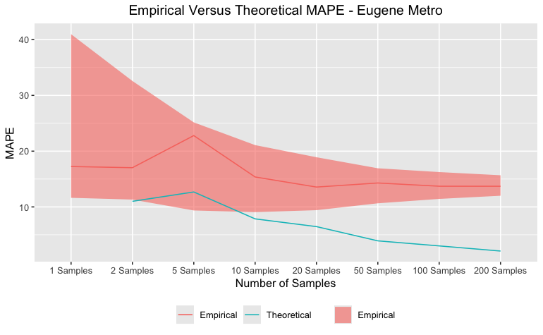

```r
## Plot the data from the code block above
ggplot(data = comparison_df_eugene, aes(x = names, y = mapes, group = mape_color)) +
  geom_line(aes(color = mape_color)) +
  geom_ribbon(aes(ymin = ci_lowers, ymax = ci_uppers, fill = mape_color), alpha = 0.6) +
  geom_line(aes(x = names, y = t_mapes, group = 1, color = tmapes_color)) +
  ggtitle("Empirical Versus Theoretical MAPE - Eugene Metro") +
  theme(plot.title = element_text(hjust = 0.5)) +
  ylab("MAPE") +
  xlab("Number of Samples") +
  theme(legend.title=element_blank()) +
  #labs(fill = "Geographic Area", color = "Geographic Area") +
  theme(legend.position = "bottom")
```